# 算法训练营Day 16

## [106.从中序与后序遍历序列构造二叉树](https://leetcode.cn/problems/construct-binary-tree-from-inorder-and-postorder-traversal/description/)

> 给定两个整数数组 inorder 和 postorder ，其中 inorder 是二叉树的中序遍历， postorder 是同一棵树的后序遍历，请你构造并返回这颗 二叉树 。

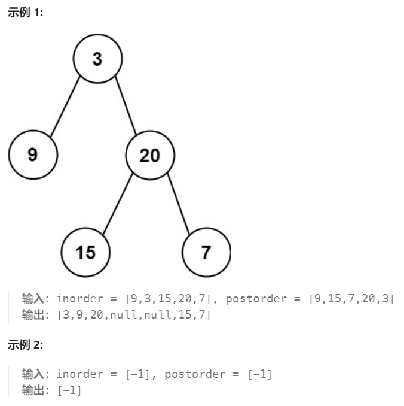

1. 递归出口  
   如果 postorder 为空，说明当前子树没有节点，直接返回 None。
2. 确定根节点  
   后序遍历的最后一个元素是当前子树的根，取  
   root_val = postorder[-1]，并创建 root = TreeNode(root_val)。
3. 在中序中定位根  
   在 inorder 中找到根的位置  
   separator_idx = inorder.index(root_val)，  
   这个位置把中序数组分成左子树和右子树两部分。
4. 切分中序数组  
   左子树的中序为 inorder[:separator_idx]  
   右子树的中序为 inorder[separator_idx + 1:]
5. 按左子树大小切分后序数组  
   左子树节点数等于 len(inorder_left)，  
   后序遍历结构是 [左子树 | 右子树 | 根]，因此  
   左子树后序为 postorder[:len(inorder_left)]  
   右子树后序为 postorder[len(inorder_left) : len(postorder) - 1]
6. 递归构建左右子树  
   root.left = buildTree(inorder_left, postorder_left)  
   root.right = buildTree(inorder_right, postorder_right)
7. 返回当前子树的根节点  
   返回 root，交给上一层递归继续拼接整棵树。

```python
# Definition for a binary tree node.
# class TreeNode:
#     def __init__(self, val=0, left=None, right=None):
#         self.val = val
#         self.left = left
#         self.right = right
class Solution:
    def buildTree(self, inorder: List[int], postorder: List[int]) -> Optional[TreeNode]:
        # 第一步: 特殊情况讨论: 树为空. (递归终止条件)
        if not postorder:
            return None

        # 第二步: 后序遍历的最后一个就是当前的中间节点.
        root_val = postorder[-1]
        root = TreeNode(root_val) # 这里要用 () 而不是 [], TreeNode 是一个类，创建节点要用 圆括号 调构造函数

        # 第三步: 找切割点.
        seperator_idx = inorder.index(root_val)

        # 第四步: 切割inorder数组. 得到inorder数组的左,右半边.
        inorder_left = inorder[:seperator_idx]
        inorder_right = inorder[seperator_idx + 1:]

        # 第五步: 切割postorder数组. 得到postorder数组的左,右半边.
        postorder_left = postorder[:len(inorder_left)]
        postorder_right = postorder[len(inorder_left):len(postorder) - 1]

        # 第六步: 递归
        root.left = self.buildTree(inorder_left, postorder_left)
        root.right = self.buildTree(inorder_right, postorder_right)

        return root
```

## [105. 从前序与中序遍历序列构造二叉树](https://leetcode.cn/problems/construct-binary-tree-from-preorder-and-inorder-traversal/)

> 给定两个整数数组 preorder 和 inorder ，其中 preorder 是二叉树的先序遍历， inorder 是同一棵树的中序遍历，请构造二叉树并返回其根节点。

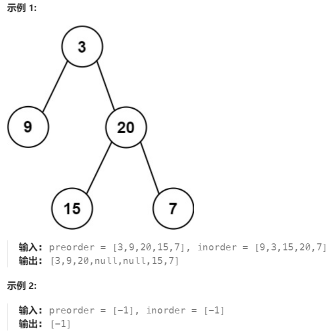

```python
# Definition for a binary tree node.
# class TreeNode:
#     def __init__(self, val=0, left=None, right=None):
#         self.val = val
#         self.left = left
#         self.right = right
class Solution:
    def buildTree(self, preorder: List[int], inorder: List[int]) -> Optional[TreeNode]:
        if not preorder:
            return None

        root_val = preorder[0]
        root = TreeNode(root_val)

        seperator_idx = inorder.index(root_val)

        inorder_left = inorder[:seperator_idx]
        inorder_right = inorder[seperator_idx + 1:]

        preorder_left = preorder[1:1 + len(inorder_left)]
        preorder_right = preorder[1 + len(inorder_left):]

        root.left = self.buildTree(preorder_left, inorder_left)
        root.right = self.buildTree(preorder_right, inorder_right)

        return root
```